# Course Project

15/06/2020

## Project Description

This 5- slide presentation accompanies the Shiny Application created for the Developing Data Projects Week 4 Course Project. This application includes the following:

1. Some form of input
2. Some operation on the ui input in sever.R
3. Some reactive output displayed as a result of server calculations
4. Enough documentation so that a novice user could use the application.
5. Documentation at the Shiny website itself.

Details can be found at: https://github.com/TDCrow/Week4Project

## Goals scored during the World Cup

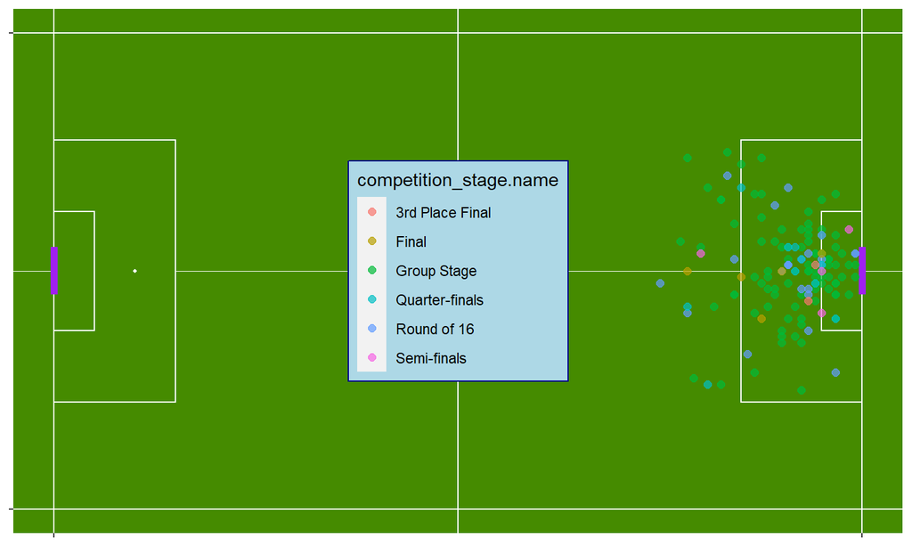

## Data

The data for this project comes from Statsbomb (see link for the github data respository: https://github.com/statsbomb/open-data). The data documents details of every goal scored in the 2018 world cup.

| competition_stage.name | total_goals |
| --- | --- |
| 3rd Place Final | 2 |
| Semi-finals | 4 |
| Final | 5 |
| Quarter-finals | 10 |
| Round of 16 | 25 |
| Group Stage | 113 |

[figure not shown]